# KFF report

Stas Kolenikov

2020-06-08

## Sample report

This KFF Health Tracking Poll was designed and analyzed by public opinion researchers at the Kaiser Family Foundation (KFF). The survey was conducted from April 11, 2019 to April 16, 2019, among a nationally representative random digit dial telephone sample of 1,203 adults ages 18 and older, living in the United States, including Alaska and Hawaii (note: persons without a telephone could not be included in the random selection process). The sample included 290 respondents reached by calling back respondents that had previously completed an interview on the KFF Tracking poll more than nine months ago. Computer-assisted telephone interviews conducted by landline (301) and cell phone (902, including (624 who had no landline telephone) were carried out in English (1137) and Spanish (66).

### MOE table

Numbers of respondents and margins of sampling error for key subgroups are shown in the table below. For results based on other subgroups, the margin of sampling error may be higher.

| Group | N (unweighted) | MOE |
| --- | --- | --- |
| Total | 1,203 | +/- 3.3 percentage points |
| Party ID |  |  |
| Democrats | 342 | +/- 6.2 percentage points |
| Republicans | 273 | +/- 6.9 percentage points |
| Independents | 544 | +/- 4.9 percentage points |
| Dem-leaning Indeps | 199 | +/- 8.3 percentage points |
| Rep-leaning Indeps | 181 | +/- 8.4 percentage points |

## Some plots

### Q1: Congress priorities

Shortened labels for plotting:

| item | main_label | better_label |
| --- | --- | --- |
| q1a | 1A. Repealing and replacing the 2010 Affordable Care Act | 1A. Repealing and replacing the ACA |
| q1b | 1B. Lowering prescription drug costs for as many Americans as possible | 1B. Lowering prescription drug costs for as many Americans as possible |
| q1c | 1C. Expanding government financial help for those who buy their own insurance coverage on the ACA marketplace to include more people | 1C. Expanding government financial help to include more people who buy their own insurance |
| q1d | 1D. Protecting people with health insurance from surprise high out-of-network medical bills | 1D. Protecting people with health insurance from surprise bills |
| q1e | 1E. Implementing a national Medicare-for-all plan, in which all Americans would get their insurance from a single government plan | 1E. Implementing a national Medicare-for-all plan |
| q1f | 1F. Making sure the Affordable Care Act’s protections for people with pre-existing health conditions continue | 1F. Continuing ACA protections for people with pre-existing conditions |

Weighted estimates:

| item | better_label | estimate | Responses |
| --- | --- | --- | --- |
| q1a | 1A. Repealing and replacing the ACA | 27.23 | Top priority |
|  |  | 25.96 | Important but not top priority |
|  |  | 10.06 | Not too important |
|  |  | 31.92 | Should not be done |
| q1b | 1B. Lowering prescription drug costs for as many Americans as possible | 68.36 | Top priority |
|  |  | 24.92 | Important but not top priority |
|  |  | 3.33 | Not too important |
|  |  | 2.65 | Should not be done |
| q1c | 1C. Expanding government financial help to include more people who buy their own insurance | 26.40 | Top priority |
|  |  | 39.46 | Important but not top priority |
|  |  | 13.00 | Not too important |
|  |  | 14.93 | Should not be done |
| q1d | 1D. Protecting people with health insurance from surprise bills | 49.63 | Top priority |
|  |  | 36.33 | Important but not top priority |
|  |  | 6.09 | Not too important |
|  |  | 5.57 | Should not be done |
| q1e | 1E. Implementing a national Medicare-for-all plan | 31.37 | Top priority |
|  |  | 26.29 | Important but not top priority |
|  |  | 7.17 | Not too important |
|  |  | 32.39 | Should not be done |
| q1f | 1F. Continuing ACA protections for people with pre-existing conditions | 63.80 | Top priority |
|  |  | 25.14 | Important but not top priority |
|  |  | 4.81 | Not too important |
|  |  | 5.43 | Should not be done |

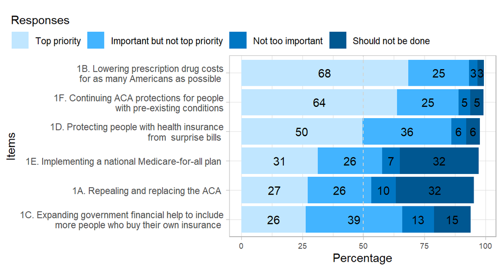

### Q6: overturn ACA

Item Q6 asks: 6. Would you like to see the Supreme Court overturn the 2010 health care law, or not?. Its response options are: 1, 2, 8, 9.

Estimates broken down by party:

| q6 | party5 | prop_cell | party3 | denom | prop_within_party | prop_overall |
| --- | --- | --- | --- | --- | --- | --- |
| 1 | 1 | 0.0329 | 1 | 0.2547 | 0.1293 | 0.3887 |
| 2 | 1 | 0.2126 | 1 | 0.2547 | 0.8346 | 0.5386 |
| 8 | 1 | 0.0051 | 1 | 0.2547 | 0.0200 | 0.0601 |
| 9 | 1 | 0.0041 | 1 | 0.2547 | 0.0160 | 0.0125 |
| 1 | 2 | 0.0277 | 3 | 0.4755 | 0.3639 | 0.3887 |
| 2 | 2 | 0.1667 | 3 | 0.4755 | 0.5487 | 0.5386 |
| 8 | 2 | 0.0031 | 3 | 0.4755 | 0.0766 | 0.0601 |
| 9 | 2 | 0.0000 | 3 | 0.4755 | 0.0107 | 0.0125 |
| 1 | 3 | 0.0591 | 3 | 0.4755 | 0.3639 | 0.3887 |
| 2 | 3 | 0.0615 | 3 | 0.4755 | 0.5487 | 0.5386 |
| 8 | 3 | 0.0234 | 3 | 0.4755 | 0.0766 | 0.0601 |
| 9 | 3 | 0.0035 | 3 | 0.4755 | 0.0107 | 0.0125 |
| 1 | 4 | 0.0863 | 3 | 0.4755 | 0.3639 | 0.3887 |
| 2 | 4 | 0.0327 | 3 | 0.4755 | 0.5487 | 0.5386 |
| 8 | 4 | 0.0099 | 3 | 0.4755 | 0.0766 | 0.0601 |
| 9 | 4 | 0.0016 | 3 | 0.4755 | 0.0107 | 0.0125 |
| 1 | 5 | 0.1595 | 5 | 0.2194 | 0.7268 | 0.3887 |
| 2 | 5 | 0.0397 | 5 | 0.2194 | 0.1809 | 0.5386 |
| 8 | 5 | 0.0170 | 5 | 0.2194 | 0.0773 | 0.0601 |
| 9 | 5 | 0.0033 | 5 | 0.2194 | 0.0151 | 0.0125 |
| 1 | 9 | 0.0233 | 9 | 0.0504 | 0.4625 | 0.3887 |
| 2 | 9 | 0.0254 | 9 | 0.0504 | 0.5046 | 0.5386 |
| 8 | 9 | 0.0017 | 9 | 0.0504 | 0.0330 | 0.0601 |
| 9 | 9 | 0.0000 | 9 | 0.0504 | 0.0000 | 0.0125 |

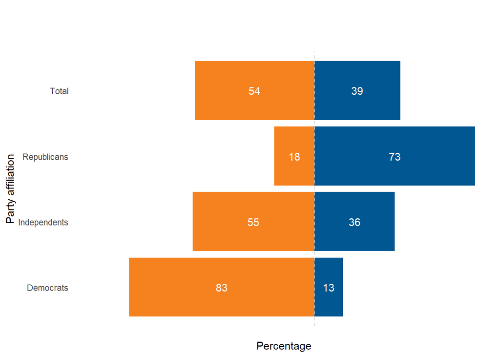